# ST443 ML Group Project

December 2023

## 1. Introduction

We would like to use socio-demographic data on the US census tract level to determine **predict** whether a given census tract experience a positive economic growth, measured by the median income.

We will be using data from the US Census Bureau that is retrieved through API requests.

```r
knitr::opts_chunk$set(echo = TRUE,results= 'hide', warning = F, message = F)

# data processing
library(dplyr)
library(tidyr)
library(stringr)
library(purrr)

# api data collection
library(httr) # return html request
library(jsonlite) # parsing json
library(glue) # formating api query

# data processing
library(dplyr)
library(tidyr)
library(stringr)
library(purrr)
library(reshape2)

# plotting packages
library(ggplot2)
library(GGally)
library(corrplot)

# model fitting package
library(ISLR)
library(glmnet)
library(caret)
library(pls)
library(MASS)
library(leaps)
library(tree)
library(randomForest)
library(class)
```

## 2. Loading the Data

The dataset is retrieved through an API request to the US Census Bureau. We defined a custom function `USCB_api_r` which returns a dataframe where each row represents a census tract, uniquely identified by a 11-digit FIPS code, and the socio-demographic idicators for a given state.

```r
# define the api query
USCB_api_r <- function(year, table, state,query, county = "*", geog_lvl = "tract"){
  # transform the state into a 2 digit fips code
  state <- sprintf(paste0("%0", 2, "d"), state)
  #` Assume all counties from the stat
  url <- glue("https://api.census.gov/data/{year}/{table}?get={query}&for={geog_lvl}:*&in=state:{state}&in=county:{county}")
  res <- httr::GET(url)

  # check if the API request is successful
  if (res$status_code == 200){
    # parse the json to data and the col names
    res_json <- httr::content(res, "text")
    col <- fromJSON(res_json, flatten = T)[1,]
    data <- fromJSON(res_json, flatten = T)[-1,]
    # parse into a df
    df <- as.data.frame(data)
    colnames(df) <- col

    # concatenate the fips column into one unique 11-digit id
    df <- df  %>%
            mutate(fips = paste(state,county,tract, sep = ""))  %>%
            subset(select = -c(state,county,tract))

  }  else {
    print("The API request failed: " + url)
    break
  }

  return(df)
}

# define custom function to run a for loop to retrieve data from all state
USCB_year_table <- function(year, table, query ){
  #states <- (1:56)[!(1:56 %in% c(3, 7, 14, 43, 52))]
  states<- c(36) # getting new york only
  datalist = vector("list", length = length(states))

  # for loop to retreive all state data
  for (state_ind in seq(1,length(states), by = 1)){
    new_data <- USCB_api_r(year,table,states[state_ind], query)
    datalist[[state_ind]] <- new_data
    print(paste("State ", states[state_ind]," df returned"))
    print(dim(new_data))
  }
  # bind all the state tables into on dataframe
  full_df<- do.call(rbind, datalist)

  return(full_df)
}
```

Since the variables we are interested are in 3 different tables, we will have to run 3 sets of for loop. The function is written such that a for loop could be used to iteratate through all state fips code to return the all observations made avaialble through the API shall we wish to expand the data source later.

The following tables listed out the variable codes and the variable names that we are interested, in addition to the table where they are stored in.

| variables | Encoding | Year | Table |
| --- | --- | --- | --- |
| Median age | B01002_001E | 2019 | acs/acs5 |
| Education Attaintment (Bachelor or Above) | B16010_041E | 2019 | acs/acs5 |
| Total population>25yo(Education Attainment) | B16010_001E | 2019 | acs/acs5 |
| Household with Social Security income | B19055_002E | 2019 | acs/acs5 |
| No. of Household (Social Security income) | B19055_001E | 2019 | acs/acs5 |
| Population (white) | B02001_002E | 2019 | acs/acs5 |
| Total population | B02001_001E | 2019 | acs/acs5 |
| Total working population in labour force | B23025_002E | 2019 | acs/acs5 |
| Civilian Labour Force in Employment | B23025_004E | 2019 | acs/acs5 |
| Total population with work experience | C18121_001E | 2019 | acs/acs5 |
| Population worked full-time | C18121_002E | 2019 | acs/acs5 |
| Population worked less than full-time | C18121_006E | 2019 | acs/acs5 |
| Population with employment sector data | B24031_001E | 2019 | acs/acs5 |
| Median income in Manufacturing Sector | B24031_006E | 2019 | acs/acs5 |
| Median income in Agricultural Sector | B24031_002E | 2019 | acs/acs5 |
| Median H. Income(2019 inflation-adjusted) | DP03_0062E | 2019 | acs/acs5/profile |
| Percentage Houshold - Owner Occupied | DP04_0046PE | 2019 | acs/acs5/profile |
| Percentage Household with Social Security | DP03_0066PE | 2019 | acs/acs5/profile |
| Population employed to Agriculture | DP03_0035PE | 2019 | acs/acs5/profile |
| Population employed to Manufacturing | DP03_0035PE | 2019 | acs/acs5/profile |
| Median H. Income(2014 inflation-adjusted) | DP03_0062E | 2014 | acs/acs5/profile |

```r
# retreive 2019 acs/acs5 data
query_acs_2019 <- 'B01002_001E,B16010_041E,B16010_001E,B19055_001E,B19055_002E,B02001_002E,B02001_001E,B23025_002E,B23025_004E,C18121_001E,C18121_002E,C18121_006E,B24031_001E,B24031_006E,B24031_002E'
acs_main_2019 <- USCB_year_table("2019", "acs/acs5",query_acs_2019 )

# retrieve 2019 acs/acs5/profile data
query_acs_profile_2019 <- "DP03_0062E,DP04_0046PE,DP03_0066PE,DP03_0033PE,DP03_0035PE"
acs_profile_2019 <- USCB_year_table("2019", "acs/acs5/profile",query_acs_profile_2019 )

# retrieve 2014 acs/acs5/profile data
query_acs_profile_2014 <- "DP03_0062E"
acs_profile_2014 <- USCB_year_table("2014", "acs/acs5/profile",query_acs_profile_2014 )
```

We merge the three tables as one complete table on the fips id.

```r
df_2019 <- merge(acs_main_2019, acs_profile_2019, by = "fips", all = TRUE)
df_full <- merge(df_2019,acs_profile_2014, by = 'fips', suffixes = c("_2019","_2014"))

#write.csv(df_full, file = "./USCB_data.csv", row.names = FALSE)
```

## 3. Data Processing

Based on a list of estimated values, we will first inspect column wise to see if there is any variable that does not have a lot of observation.

Then we will look row-wise to see if any census tracts does not have sufficient data.

For details of the estimate value encoding, see: https://www.census.gov/data/developers/data-sets/acs-1year/notes-on-acs-estimate-and-annotation-values.html

```r
# Inspect the distribution of estimated vals
est_val <- as.numeric(c(-666666666,-999999999,-888888888,-222222222,-333333333,-555555555, NULL))
# concert all column as numeric
df_full <- df_full %>% mutate_at(2:22, as.numeric)
# Column-wise count of values in the given vector
column_count <- colSums(df_full == est_val)
# Print the result
print(column_count)
dim(df_full)[1]
```

We observe that across the columns for employment details (B24031_002E, B24031_006E), a lot of the census tract has too little of a sample size for a good estimate. Dropping these rows naively will significantly reduce the size of the dataset. Hence, we will assume that there is no individual employed into the given sector by replacing the value with 0.

```r
# filter the data frame
df <- df_full %>%
        mutate(across(all_of(c("B24031_002E", "B24031_006E","DP03_0033PE","DP03_0035PE")),
                ~ ifelse(. == -666666666, 0, .)))  %>%
        filter_all(all_vars(!. %in% est_val))
```

In the cleaning process, 134 out of 4918 is dropped from the dataframe. For more rigorous study, we should look at the distribution of the census tract being dropped. However, this is beyond the scope of this study, hence we will naively dropped them.

We will now compute additional variables, namely by taking percentages rather than absolute value. For example, rather than the aboslute number, we want to get the percentage of population over 25 year-old to have obtained a Bachelor’s Degree or Above computed as follow:
$$B16010\_0041PE= \frac{B16010\_041E
}{B16010\_001E}$$

Note that we will simply change the suffix of the indicator for convenience with “PE” that is consistent with the US Census Bureau convention.

In addition, we will also compute the percentage change in income (DP03_0062E_delta) and create a new categorical variable that classify census tracts into groups where median income has increased and decreased (INC_DELTA_K).

```r
# compute the percentages
df_processed <- df  %>%
        mutate(B16010_041PE = B16010_041E / B16010_001E,
                B19055_002PE = B19055_002E / B19055_001E,
                B02001_002PE = B02001_002E / B02001_001E,
                B23025_004PE = B23025_004E / B23025_002E,
                C18121_002PE = C18121_002E / C18121_001E,
                C18121_006PE = C18121_006E / C18121_001E,
                DP03_0062E_delta = (DP03_0062E_2019 - DP03_0062E_2014)/ DP03_0062E_2014,
                INC_DELTA_K = ifelse((DP03_0062E_2019 - DP03_0062E_2014)/ DP03_0062E_2014 >0, "up",'down'),
                DP04_0046PE = DP04_0046PE/ 100, # standardized percentage as decimal
                DP03_0066PE = DP03_0066PE/100,
                DP03_0033PE = DP03_0033PE/100,
                DP03_0035PE = DP03_0035PE/100,
                fips = str_pad(fips, width = 11, side = "left", pad = "0"))
# add a column for state_fips (useful if contain more than one state)
df_processed <- df_processed  %>%
        mutate(fips_state = substr(fips, 1,2))

# inspect the result
summary(df_processed)

# Subset rows with either infinity or NaN values
na_inf_df <- df_processed %>%
  filter_all(any_vars(is.na(.) | is.infinite(.)))
dim(na_inf_df)
# fill the nan value as 0
df_processed <- df_processed %>%
        filter_all(all_vars(!. %in% est_val))

#write.csv(df_processed, file = "./USCB_data_cleaned.csv", row.names = FALSE)
#head(df_processed)
```

## 4. Data Exploration

We check the correlation between the variables by plotting the following heatmap

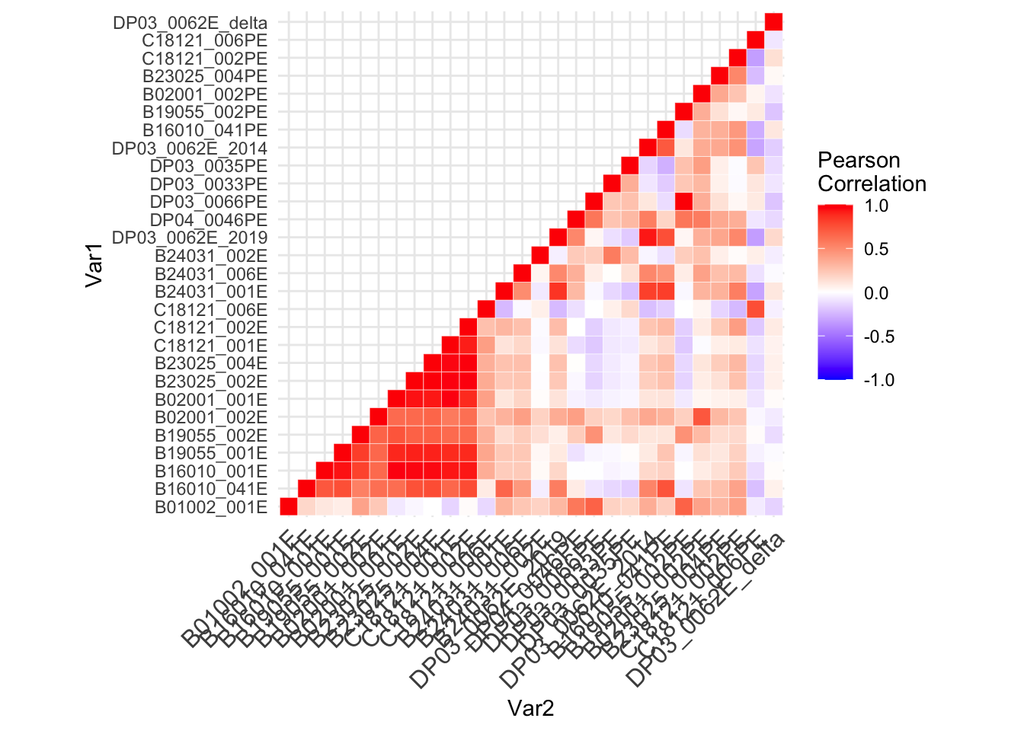

```r
# plot correlation heatmap
corr_df <- df_processed  %>%
                subset(select = -c(fips,INC_DELTA_K,fips_state))
corr_mat <- cor(corr_df)

# take only the lower triangle of corr_matrix
get_lower_tri<-function(cormat){
cormat[lower.tri(cormat)] <- NA
return(cormat)
}
corr_mat_l <- get_lower_tri((corr_mat))

# draw heat map
melted_cormat <- melt(corr_mat_l, na.rm = TRUE)
ggplot(data = melted_cormat, aes(Var2, Var1, fill = value))+
 geom_tile(color = "white")+
 scale_fill_gradient2(low = "blue", high = "red", mid = "white",
   midpoint = 0, limit = c(-1,1), space = "Lab",
   name="Pearson\nCorrelation") +
  theme_minimal()+
 theme(axis.text.x = element_text(angle = 45, vjust = 1,
    size = 12, hjust = 1))+
 coord_fixed()
```

## 5. Model Fitting

We remove the columns that are redundant for the model fitting process.

```r
df <- df_processed  %>%
        filter(fips_state == "36")  %>% # getting only the NY data
        mutate(INC_DELTA_K = as.factor(INC_DELTA_K))  %>%
        subset(select = -c(DP03_0062E_2019, DP03_0062E_2014,fips_state, fips))
head(df)
```

We then apply train-test split to model fiting and evalaution. We also create a hold-out validation set that could be use after we have selected the bets approach and conduct a final evaluation. The three sets of data are stored in to a list object `res_df`.

```r
# split between train, test and validation set into a list of result dfs
set.seed(2023)
spec <- c(train = .6, test = .2, validate = .2)
g <- sample(cut(seq(nrow(df)),  nrow(df)*cumsum(c(0,spec)), labels = names(spec)
        ))
res_df <- split(df, g)
```

### 5.1 Regression Model

We will run a linear regression model, including all the variables to see the interaction between the predictors and the response variable.

```r
time1 <- Sys.time()
lmodel <- lm(DP03_0062E_delta ~ . - INC_DELTA_K, data = res_df$train)
sm_lm <- summary(lmodel)
sm_lm

lpred <- predict(lmodel, newdata = res_df$test)
time.linear <- (Sys.time()-time1)

#Calculating Mean Squared Error (MSE) on testing data
linearmse <- mean((res_df$test$DP03_0062E_delta - lpred)^2)
linearmsesqt <- (linearmse)^(1/2)
```

Having naively fitted an OLS model, we observed that there exists some relationships between the change in medium income and the social-demographic data that we have used. We will now determine which variables should be excluded by applying regularization with Lasso Regression and subsequently consider the best subset.

#### 5.1.1 Regularization with Lasso Regression

We will first use the training data to determine the best $\lambda$.

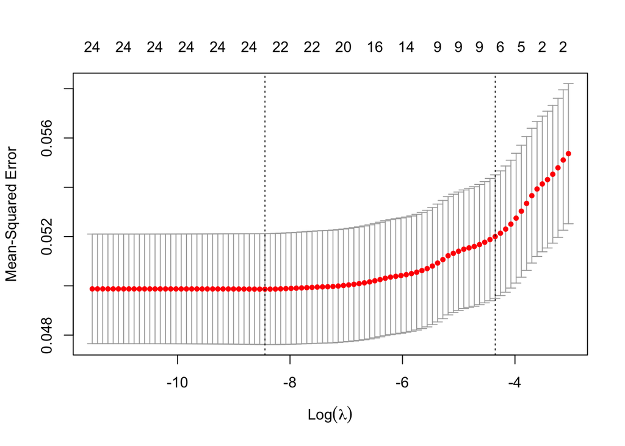

```r
# define the model matrix
x_train <- model.matrix(DP03_0062E_delta~.-1, data = res_df$train[1:26])
y_train <- res_df$train$DP03_0062E_delta
x_test <- model.matrix(DP03_0062E_delta~.-1, data = res_df$test[1:26])
y_test <- res_df$test$DP03_0062E_delta

# fit the model
cv.lasso <- cv.glmnet(x_train, y_train, alpha=1)
plot(cv.lasso)
```

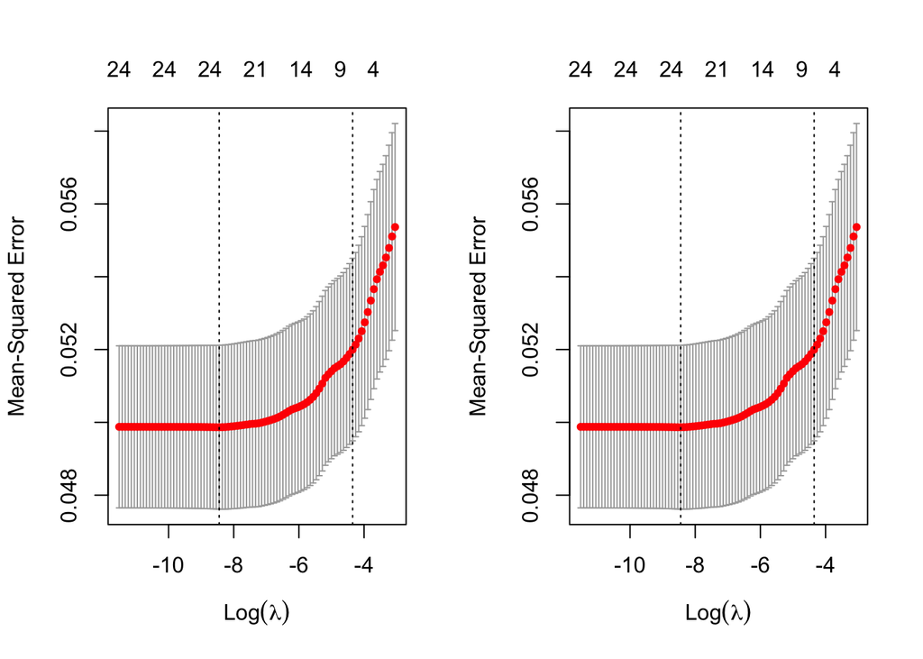

```r
coef(cv.lasso)

# plot the model metrics
par(mfrow = c(1,2))
plot(cv.lasso, xvar="lambda", label= TRUE)
plot(cv.lasso, xvar="dev", label= TRUE)
```

```r
par(mfrow = c(1,1))

# save the result of the best model
coef <- coef(glmnet(x_train,y_train,alpha=1, lambda=cv.lasso$lambda.min))
indices <- which(coef != 0 , arr.ind = TRUE)
predictors <- dimnames(indices)[[1]][-1]
```

```r
# define the final model using lasso
lasso <- glmnet(x_train,y_train,lambda = cv.lasso$lambda.min)
lasso_predict <- predict(lasso,x_test)
# compute the test RMSE
rmse_lasso <- sqrt(apply((y_test - lasso_predict)^2,2,mean))
```

With $\lambda = 2.1488139\times 10^{-4}$, we yield a model that has a $RMSE_{test} = 0.2267227$

```r
time1 <- Sys.time()
cv.lasso <- cv.glmnet(x_train, y_train, alpha=1)
lasso <- glmnet(x_train,y_train,lambda = cv.lasso$lambda.min)
lasso_predict <- predict(lasso,x_test)
time.lasso <- (Sys.time()-time1)
```

#### 5.1.2 Best Subset MLR

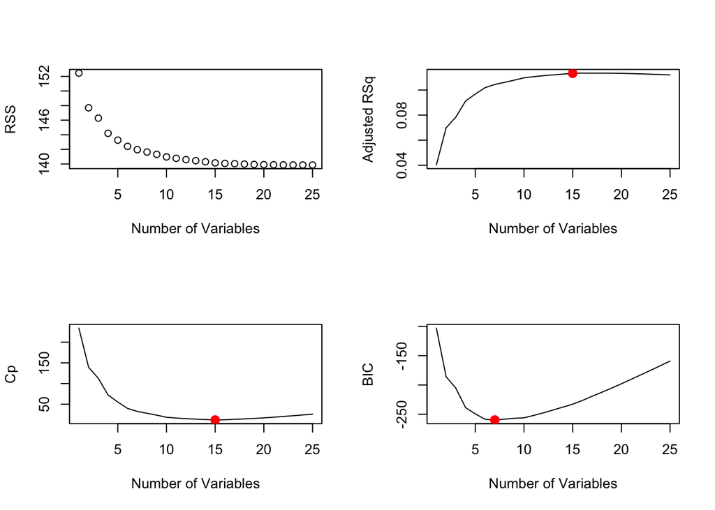

```r
# fit the model
regfit_full <- regsubsets(DP03_0062E_delta ~.- INC_DELTA_K,
                data = res_df$train, nvmax = 25)
reg_summary <- summary(regfit_full)


# plot resquare
par(mfrow=c(2,2))
# plot RSS
plot(reg_summary$rss, xlab="Number of Variables", ylab="RSS")
# plot adjusted r squared
plot(reg_summary$adjr2, xlab="Number of Variables", ylab="Adjusted RSq", type="l")
best_model <- which.min(reg_summary$cp)
points(best_model, reg_summary$adjr2[best_model], col="red", cex=2, pch=20)
#  plot Cp
plot(reg_summary$cp, xlab="Number of Variables", ylab="Cp", type="l")
best_model <- which.min(reg_summary$cp)
points(best_model, reg_summary$cp[best_model], col="red", cex=2, pch=20)
# plot BIC
plot(reg_summary$bic, xlab="Number of Variables", ylab="BIC", type="l")
best_model <- which.min(reg_summary$bic)
points(best_model, reg_summary$bic[best_model], col="red", cex=2, pch=20)
```

```r
# parse the best subset result by r squared
n_predictors <- which.max(reg_summary$adjr2)
predictors <- names(reg_summary$which[n_predictors, reg_summary$which[n_predictors,]])[-1]
```

Under different information criterion, however, the optimal model identified is different. From this result, we observe that the best performing model uses $16$ predictors including B01002_001E, B16010_041E, B16010_001E, B19055_001E, B19055_002E, B02001_002E, B23025_004E, C18121_001E, C18121_002E, B24031_001E, B24031_006E, B24031_002E, DP04_0046PE, B02001_002PE, C18121_002PE, C18121_006PE.

This model yields an adjusted $R^2$ of 0.1135081 on the training data set.

For the full result, this can be inspected using the plots below.

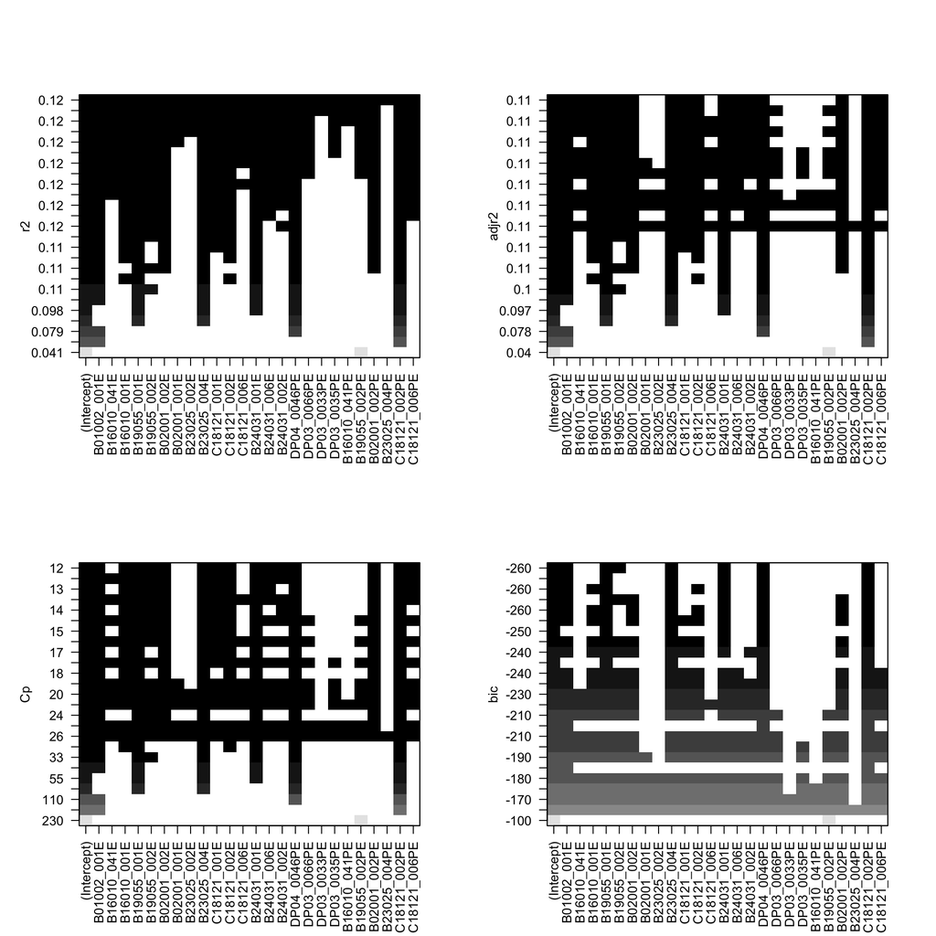

```r
par(mfrow=c(2,2))
plot(regfit_full, scale="r2")
plot(regfit_full, scale="adjr2")
plot(regfit_full, scale="Cp")
plot(regfit_full, scale="bic")
```

With the model that we selected, we compute the $RMSE_{test}$ so we can compare it with other models yielded from other methods later.

```r
# define function to get the prediction using the best model
predict_regsubsets <- function(object, newdata, id, ...) {
  form = as.formula(object$call[[2]])
  mat = model.matrix(form, newdata)
  coef_i = coef(object, id = id)
  mat[, names(coef_i)] %*% coef_i
}
# compute the RMSE
pred <- predict_regsubsets(regfit_full,res_df$test, id = which.max(reg_summary$adjr2))
rmse_bestsubset <- sqrt(mean((res_df$test$DP03_0062E_delta- pred)^2))
```

From this optimal model we selected, we yield a $RMSE_{test} = 0.2268446$

```r
time1 <- Sys.time()
regfit_full <- regsubsets(DP03_0062E_delta ~.- INC_DELTA_K,
                data = res_df$train, nvmax = 25)
pred <- predict_regsubsets(regfit_full,res_df$test, id = which.max(reg_summary$adjr2))
time.bestsubset <- (Sys.time()- time1)
```

#### 5.1.3 Principal Component Regression

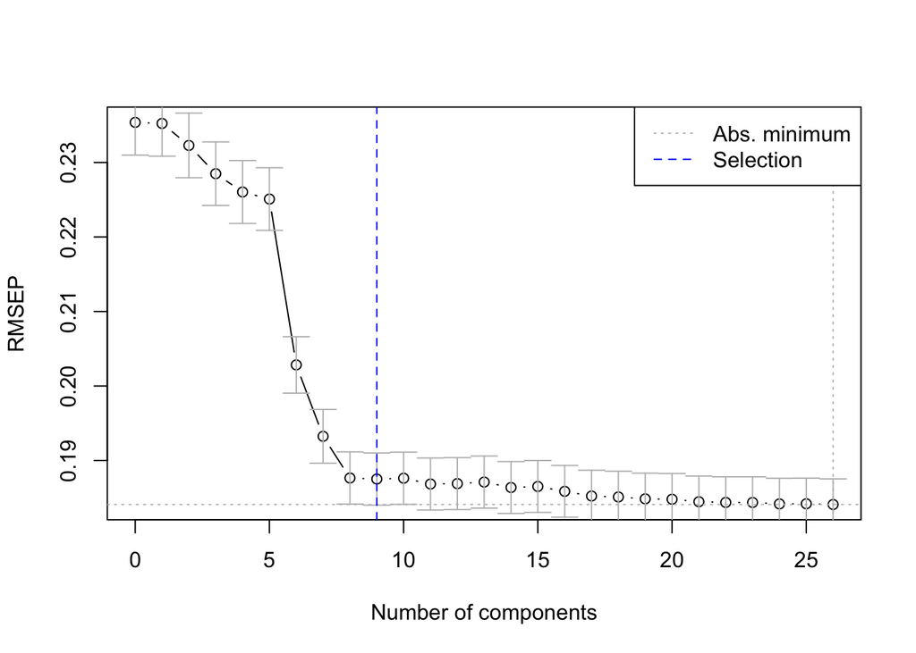

```r
# fit the model
time1 <- Sys.time()
pcr_model <- pcr(DP03_0062E_delta~ ., data = res_df$train,
                validation = "CV", scale = T)
sm_pcr <- summary(pcr_model)
# "selectNcomp()" Choosing the best number of components in PCR.
# "method = `onesigma`" implies the "1 stdandard error rule".
selectNcomp(pcr_model, method = "onesigma", plot = TRUE)
```

```r
# Predicted values
pcrpred= predict(pcr_model, newdata = res_df$test)
time.pcr <- (Sys.time()- time1)

#Calculating Mean Squared Error (MSE)
mse= mean((res_df$test$DP03_0062E_delta - pcrpred)^2)
rmse_pcr=(mse)^(1/2)
```

From this model trained under the PCA algorithm, it yields a $RMSE_{test} = 0.1995219$

#### 5.1.4 Model Validation

| Regression Methods | Measure(Root MSE) | Time Taken(in seconds) |
| --- | --- | --- |
| Linear Regression | 0.2272314 | 0.0262010097503662 |
| Lasso | 0.2267227 | 0.0706770420074463 |
| Best Subset | 0.2268446 | 0.0228719711303711 |
| Principal Component Regression | 0.1995219 | 0.234659910202026 |

Comparing the result from the above, lasso and best subset showed similar performance. We moved forward with LASSO Regression because the LASSO regression has a good functional form. While the best subset are more flexibile, providing better control since we could choose between AIC, $C_p$, adjusted $R^2$ and BIC to evaluate our model, we think that it will be harder to reproduce at scale when we want to apply the model again to another dataset, say for a neighbouring state.

```r
x_val=model.matrix(DP03_0062E_delta~.-1, data = res_df$validate[1:26])
y_val=res_df$validate$DP03_0062E_delta
lasso_predict <- predict(lasso,x_val)
#compute the test RMSE
val_lasso <- sqrt(apply((y_val - lasso_predict)^2,2,mean))
```

### 5.2 Classification Problem

As observed from the section above, the machine learning models employed perform rather poorly on the data set.

While this is not uncommon for economic study to have such a low $R^2$, we would like to see if simplifying the research question to one of classification will yield better result.

```r
classification_matrix <- function(confusion_matrix){
        #' return the specificity, sensitivity, and accuracy given a confusion matrix
        #' here sensitive refers to sensitive to detecting decrease in income
        sens <- confusion_matrix[1,1] / (confusion_matrix[1,1] + confusion_matrix[2,1])
        spec <- confusion_matrix[2,2] / (confusion_matrix[2,2] + confusion_matrix[1,2])
        accu <- (confusion_matrix[1,1] + confusion_matrix[2,2]) / sum(confusion_matrix)
        return(list(spec = spec, sens = sens, accu = accu))
}
```

#### 5.2.1 Logistic Regression

```r
# Specify type of training method used and the number of folds
ctrlspecs <- trainControl(method="cv",
                          number=5,
                          savePredictions="all",
                          classProbs=TRUE)
logit <- train(INC_DELTA_K ~ . - DP03_0062E_delta, data=res_df$train,
                method="glm",
                family=binomial,
                trControl=ctrlspecs)
print(logit)
```

We used the Cross-Validation Method to evaluate the best subset model. Althoug the `leaps::regsubsets()` can help us identify the best subset of variable used for the logistic regression, it does not provide an intuitive evaluation matrix that we could use to compare the results. Hence, we wrote a custom function which runs through $k$-fold iteration for comparing the model by classification accuracy.

```r
# create a function for variable selection using cross validation
logistic_cv <- function(data_train, k = 5, nvmax = NULL) {
        if (is.null(nvmax)){
                nvmax <- dim(data_train)[2]-1
        }
        #` Conduct a best subset search for variable selection under logistic regression
        p <- dim(data)[2] - 1 # exclude the response
        cv.accu <- rep(NA, times = nvmax) # the train approach can only return accuracy

        # return the best subset by number of variables
        logit_subset <- regsubsets(INC_DELTA_K ~ ., data = cv_data, nvmax = nvmax)
        logit_summary <- summary(logit_subset)

        for (i in 1:nvmax){
                #print(sprintf("looping through %d variable model", i))
                variables_vect <- names(logit_summary$which[i,][which(logit_summary$which[i,])])[-1]
                df <- data_train  %>%
                        subset(select = c(variables_vect, "INC_DELTA_K"))
                # apply the logistic regression
                ctrlspecs <- trainControl(method="cv",
                          number=5,
                          savePredictions="all",
                          classProbs=TRUE)
                logit <- train(INC_DELTA_K ~ ., data= df,
                                method="glm",
                                family=binomial,
                                trControl=ctrlspecs)
                # return the accuracy rate
                cv.accu[i] <- logit$results$Accuracy

        }
        return(list(accuracy = cv.accu,logit_summary = logit_summary))
}

# cv
cv_data <- res_df$train  %>% subset(select = c(-DP03_0062E_delta))
logistic_cv_result <- logistic_cv(cv_data)

# parse the result
max_accu <- max(logistic_cv_result$accuracy)
n_predictors <- which.max(logistic_cv_result$accuracy)
best_subset_result <- logistic_cv_result$logit_summary
vars <- names(best_subset_result$which[n_predictors,][which(best_subset_result$which[n_predictors,])])[-1]
```

Using the cross-validation approach, we determined that the model with 5 has the highest prediction accuracy, namely it identifies B01002_001E, B19055_001E, B23025_002E, B02001_002PE, C18121_002PE as the predictors for the logistic regression.

```r
# define the train and test data set for the best subset
df_train <- res_df$train  %>% subset(select= c(vars, "INC_DELTA_K"))
df_test <- res_df$test  %>% subset(select= c(vars, "INC_DELTA_K"))

logit <- glm(INC_DELTA_K~.,data = df_train,family = binomial)
summary(logit)

# predict on the test set
glm_probs <- predict(logit, df_test, type = "response")
# codity the probabilty to binary variable
direction_test <- rep("down", length(glm_probs))
direction_test[glm_probs > .5] <- "up"

# output the confusion matrix
logit_conf_m <- table(direction_test, df_test$INC_DELTA_K)
logit_error <- mean(direction_test != df_test$INC_DELTA_K)
logit_matrics <- classification_matrix(logit_conf_m)
```

With this logistic regression model, we yield a misclassification error rate of 0.1640543.

```r
#time taken by Logistics
time1 <- Sys.time()
logistic_cv <- function(data_train, k = 5, nvmax = NULL) {
        if (is.null(nvmax)){
                nvmax <- dim(data_train)[2]-1
        }
        #` Conduct a best subset search for variable selection under logistic regression
        p <- dim(data)[2] - 1 # exclude the response
        cv.accu <- rep(NA, times = nvmax) # the train approach can only return accuracy

        # return the best subset by number of variables
        logit_subset <- regsubsets(INC_DELTA_K ~ ., data = cv_data, nvmax = nvmax)
        logit_summary <- summary(logit_subset)

        for (i in 1:nvmax){
                #print(sprintf("looping through %d variable model", i))
                variables_vect <- names(logit_summary$which[i,][which(logit_summary$which[i,])])[-1]
                df <- data_train  %>%
                        subset(select = c(variables_vect, "INC_DELTA_K"))
                # apply the logistic regression
                ctrlspecs <- trainControl(method="cv",
                          number=5,
                          savePredictions="all",
                          classProbs=TRUE)
                logit <- train(INC_DELTA_K ~ ., data= df,
                                method="glm",
                                family=binomial,
                                trControl=ctrlspecs)
                # return the accuracy rate
                cv.accu[i] <- logit$results$Accuracy

        }
        return(list(accuracy = cv.accu,logit_summary = logit_summary))
}

# cv
cv_data <- res_df$train  %>% subset(select = c(-DP03_0062E_delta))
logistic_cv_result <- logistic_cv(cv_data)

# parse the result
max_accu <- max(logistic_cv_result$accuracy)
n_predictors <- which.max(logistic_cv_result$accuracy)
best_subset_result <- logistic_cv_result$logit_summary
vars <- names(best_subset_result$which[n_predictors,][which(best_subset_result$which[n_predictors,])])[-1]
logit <- glm(INC_DELTA_K~.,data = df_train,family = binomial)
# predict on the test set
glm_probs <- predict(logit, df_test, type = "response")
# codity the probabilty to binary variable
direction_test <- rep("down", length(glm_probs))
direction_test[glm_probs > .5] <- "up"


df_train <- res_df$train  %>% subset(select= c(vars, "INC_DELTA_K"))
df_test <- res_df$test  %>% subset(select= c(vars, "INC_DELTA_K"))

logit <- glm(INC_DELTA_K~.,data = df_train,family = binomial)
summary(logit)

# predict on the test set
glm_probs <- predict(logit, df_test, type = "response")
# codity the probabilty to binary variable
direction_test <- rep("down", length(glm_probs))
direction_test[glm_probs > .5] <- "up"

time.logit <- (Sys.time()- time1)
```

#### 5.2.2 Linear Discriminant Analysis

```r
# fit the model
time1 <- Sys.time()
lda_fit <- lda(INC_DELTA_K~.- DP03_0062E_delta, data=res_df$train)
lda_fit

# get the prediction
lda_pred <- predict(lda_fit, res_df$test)
lda_pred$class

time.lda <- (Sys.time()-time1)

# compute the confusion matrix
lda_conf_m <- table(lda_pred$class, res_df$test$INC_DELTA_K)
lda_error <- mean(lda_pred$class != res_df$test$INC_DELTA_K)
lda_matrics <- classification_matrix(lda_conf_m)
```

With the linear discrimant analysis, we yield an error rate of 0.1619645.

#### 5.2.3 Quadratic Discriminant Analysis

```r
# fit the model
time1 <- Sys.time()
qda_fit <- qda(INC_DELTA_K ~ . - DP03_0062E_delta,
                data = res_df$train)
qda_fit

# get prediction on testing data
qda_pred <- predict(qda_fit, res_df$test)

time.qda <- (Sys.time()-time1)

# confusion matrix and error rate
qda_conf_m <- table(qda_pred$class, res_df$test$INC_DELTA_K)
qda_error <- mean(qda_pred$class != res_df$test$INC_DELTA_K)
qda_matrics <- classification_matrix(qda_conf_m)
```

While the overall accuracy is lower than the LDA model, we observe that the QDA is more sensitive to tracts with decrease in economic performance.

#### 5.2.4 K Nearest Neighbours

```r
time1 <- Sys.time()
kvals<-data.frame(k = seq(1, 135, by = 1))
train_x<-res_df$train[,-which(names(res_df$train)=="INC_DELTA_K")]
test_x<-res_df$test[,-which(names(res_df$test)=="INC_DELTA_K")]
train_y<-res_df$train$INC_DELTA_K
test_y<-res_df$test$INC_DELTA_K

ctrl<-trainControl(method = "cv", number = 5)

knn_model<-train(x = train_x, y = train_y, method = "knn",
                   trControl = ctrl, tuneGrid = kvals)

bestk<-knn_model$bestTune$k

# get prediction on the testing data set
knn_pred<-knn(train_x, test_x, train_y, k = bestk, prob = F)

# return the evaluation metrics
time.knn <- (Sys.time()-time1)
table<-table(knn_pred, test_y)
knn_error<-mean(knn_pred!=test_y)
knn_matrics <- classification_matrix(table)
```

We do observe here that knn classifies everything to “up” category. This is also influenced by the bigger class imbalance here.

#### 5.2.5 Classification Tree

```r
tree_inc <- tree(INC_DELTA_K ~ .- DP03_0062E_delta,
                data = res_df$train,
                )
tree_inc
```

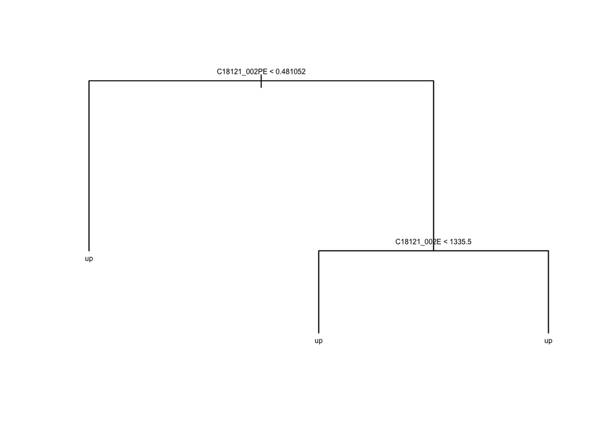

```r
plot(tree_inc)
text(tree_inc, pretty = 0, cex = 0.5)
```

From the tree diagram, we could see that the classification tree always assign an observation with an “up” label and fails to identify any census tracts that has a decrease in median income. Since the “full tree” trained by the algorithm is close to a stump and the predicted outcome is always an *increase in in median income*, we assumed that a simple tree is not suitable for this problem and did not proceed to prune the tree further. Instead, we move on to use more complex tree-based model to see if the performance would improve.

#### 5.2.6 Random Forest

```r
time1 <- Sys.time()

# model fitting
rfor_inc <- randomForest(INC_DELTA_K ~ .- DP03_0062E_delta,
                data = res_df$train,
                mtry = 13,
                )

# predict on the test data
rfor_pred <- predict(rfor_inc, newdata = res_df$test)

# return the metric
rfor_conf_m <- table(rfor_pred ,res_df$test$INC_DELTA_K)
rfor_matrics <- classification_matrix(rfor_conf_m)
time.rf <- (Sys.time()-time1)
```

Using a Random Forest algorithm, we could see an improvement in the predicted values. Although a lot of the “down” observation is still misclassified as “up” with The training set (missclassification rate of 0.9623762)

### 5.2.7 Model Evaluation

| Classification Method | Accuracy | Sensitivity | Specificity | Time Taken(in seconds) |
| --- | --- | --- | --- | --- |
| Logistics Regression | 0.8359457 | 0.0193548 | 0.9937656 | 3.80460715293884 |
| Linear Discriminant Analysis | 0.8380355 | 0.0516129 | 0.9900249 | 0.0210278034210205 |
| Quadratic Discriminant Analysis | 0.7523511 | 0.3806452 | 0.8241895 | 0.0143370628356934 |
| K Nearest Neighbour | 0.8380355 | 0 | 1 | 26.7207908630371 |
| Random Forest | 0.8390805 | 0.083871 | 0.9850374 | 3.40481615066528 |

We will now use what we identified as the best model to see how it perform on unseen validation dataset.

```r
# apply the model on res_df$validate
qda_pred_valid <- predict(qda_fit, res_df$validate)

# return confusion matrix
qda_valid_conf_m <- table(qda_pred_valid$class, res_df$validate$INC_DELTA_K)
qda_erroir <- mean(qda_pred_valid$class != res_df$validate$INC_DELTA_K)
qda_matric_valid <- classification_matrix(qda_valid_conf_m)
```

With this final classification model, we determined that the accuracy, sensistivity, and specificity on the validation dataset as follow:

| Accuracy | Sensitivity | Specificity |
| --- | --- | --- |
| 0.7345873 | 0.2848837 | 0.833121 |